# Caso 5. Bosques Aleatorios con datos adevtising. Programamción R

Luis Alberto Jimenez Soto

2022-10-12

# 1 Objetivo

Crear y evaluar un modelo de arboles aleatotios (*random forest)* para predecir las ventas con datos simulados de una empresa dependiendo de las inversiones realizadas en publicidad.

# 2 Descripción

- Cargar librerías y datos
- Limpiar datos si es necesario
- Explorar datos
- Partir los datos en datos de entrenamiento y datos de validación 70% y 30%
- Crear modelo de árbol de regresión con los datos de entrenamiento
- Hacer Predicciones con datos de validación
- Evaluar predicciones
- Determinar el estadístico *rmse* para evaluar con respecto a otros modelos
- Interpretar el caso

# 3 Fundamento teórico

Un modelo **Random Forest** está formado por un conjunto (*ensemble*) de árboles de decisión individuales, cada uno entrenado con una muestra aleatoria extraída de los datos de entrenamiento originales mediante bootstrapping. Esto implica que cada árbol se entrena con unos datos ligeramente distintos.

En cada árbol individual, las observaciones se van distribuyendo por bifurcaciones (nodos) generando la estructura del árbol hasta alcanzar un nodo terminal. La predicción de una nueva observación se obtiene agregando las predicciones de todos los árboles individuales que forman el modelo.

Para entender cómo funcionan los modelos **Random Forest** es necesario conocer primero los conceptos de *ensemble* y *bagging*.

## 3.1 Métodos de ensemble

Todos los modelos de aprendizaje estadístico y *machine learning* sufren el problema de equilibrio entre bias y varianza.

El término bias (sesgo) hace referencia a cuánto se alejan en promedio las predicciones de un modelo respecto a los valores reales. Refleja cómo de capaz es el modelo de aprender la relación real que existe entre los predictores y la variable respuesta. Por ejemplo, si la relación sigue un patrón no lineal, por muchos datos de los que se disponga, un modelo de regresión lineal no podrá modelar correctamente la relación, por lo que tendrá un bias alto.

El término varianza hace referencia a cuánto cambia el modelo dependiendo de los datos utilizados en su entrenamiento. Idealmente, un modelo no debería modificarse demasiado por pequeñas variaciones en los datos de entrenamiento, si esto ocurre, es porque el modelo está memorizando los datos en lugar de aprender la verdadera relación entre los predictores y la variable respuesta. Por ejemplo, un modelo de árbol con muchos nodos, suele variar su estructura con que apenas cambien unos pocos datos de entrenamiento, tiene mucha varianza.

A medida que aumenta la complejidad de un modelo, este dispone de mayor flexibilidad para adaptarse a las observaciones, reduciendo así el bias y mejorando su capacidad predictiva. Sin embargo, alcanzado un determinado grado de flexibilidad, aparece el problema de [*overfitting*](https://en.wikipedia.org/wiki/Overfitting), el modelo se ajusta tanto a los datos de entrenamiento que es incapaz de predecir correctamente nuevas observaciones. El mejor modelo es aquel que consigue un **equilibrio óptimo entre bias y varianza**.

¿Cómo se controlan el bias y varianza en los modelos basados en árboles? Por lo general, los árboles pequeños (pocas ramificaciones) tienen poca varianza pero no consiguen representar bien la relación entre las variables, es decir, tienen bias alto. En contraposición, los árboles grandes se ajustan mucho a los datos de entrenamiento, por lo que tienen muy poco bias pero mucha varianza. Una forma de solucionar este problema son los métodos de *ensemble*.

Los métodos de *ensemble* combinan múltiples modelos en uno nuevo con el objetivo de lograr un equilibro entre bias y varianza, consiguiendo así mejores predicciones que cualquiera de los modelos individuales originales. Dos de los tipos de *ensemble* más utilizados son:

- **Bagging**: Se ajustan múltiples modelos, cada uno con un subconjunto distinto de los datos de entrenamiento. Para predecir, todos los modelos que forman el agregado participan aportando su predicción. Como valor final, se toma la media de todas las predicciones (variables continuas) o la clase más frecuente (variables categóricas). Los modelos *Random Forest* están dentro de esta categoría.
- **Boosting**: Se ajustan secuencialmente múltiples modelos sencillos, llamados *weak learners*, de forma que cada modelo aprende de los errores del anterior. Como valor final, al igual que en *bagging*, se toma la media de todas las predicciones (variables continuas) o la clase más frecuente (variables cualitativas). Tres de los métodos de *boosting* más empleados son *AdaBoost*, *Gradient Boosting* y *Stochastic Gradient Boosting*.

Aunque el objetivo final es el mismo, lograr un balance óptimo entre bias y varianza, existen dos diferencias importantes:

- Forma en que consiguen reducir el error total. El error total de un modelo puede descomponerse como $bias+varianza+ϵ$.

En *bagging*, se emplean modelos con muy poco bias pero mucha varianza, agregándolos se consigue reducir la varianza sin apenas inflar el bias. En *boosting*, se emplean modelos con muy poca varianza pero mucho bias, ajustando secuencialmente los modelos se reduce el bias. Por lo tanto, cada una de las estrategias reduce una parte del error total.

- Forma en que se introducen variaciones en los modelos que forman el *ensemble*. En *bagging*, cada modelo es distinto del resto porque cada uno se entrena con una muestra distinta obtenida mediante bootstrapping. En *boosting*, los modelos se ajustan secuencialmente y la importancia (peso) de las observaciones va cambiando en cada iteración, dando lugar a diferentes ajustes.

La clave para que los métodos de *ensemble* consigan mejores resultados que cualquiera de sus modelos individuales es que, los modelos que los forman, sean lo más diversos posibles (sus errores no estén correlacionados). Una analogía que refleja este concepto es la siguiente: supóngase un juego como el *trivial* en el que los equipos tienen que acertar preguntas sobre temáticas diversas. Un equipo formado por muchos jugadores, cada uno experto en un tema distinto, tendrá más posibilidades de ganar que un equipo formado por jugadores expertos en un único tema o por un único jugador que sepa un poco de todos los temas.

A continuación, se describe con más detalle la estrategia de *bagging*, sobre la que se fundamenta el modelo **Random Forest**.

## 3.2 Bagging

El término *bagging* es el diminutivo de *bootstrap aggregation*, y hace referencia al empleo del muestreo repetido con reposición bootstrapping con el fin de reducir la varianza de algunos modelos de aprendizaje estadístico, entre ellos los basados en árboles.

Dadas $n$ muestras de observaciones independientes $Z_1, ... Z_n$, cada una con varianza $\sigma^2$, la varianza de la media de las observaciones $\bar{Z}$ es $\sigma^2 / n$.

En otras palabras, promediando un conjunto de observaciones se reduce la varianza.

Basándose en esta idea, una forma de reducir la varianza y aumentar la precisión de un método predictivo es obtener múltiples muestras de la población, ajustar un modelo distinto con cada una de ellas, y hacer la media (la moda en el caso de variables cualitativas) de las predicciones resultantes.

Como en la práctica no se suele tener acceso a múltiples muestras, se puede simular el proceso recurriendo a bootstrapping, generando así *pseudo-muestras* con los que ajustar diferentes modelos y después agregarlos. A este proceso se le conoce como *bagging* y es aplicable a una gran variedad de métodos de regresión.

En el caso particular de los árboles de decisión, dada su naturaleza de bajo bias y alta varianza, *bagging* ha demostrado tener muy buenos resultados. La forma de aplicarlo es:

Generar BB *pseudo-training sets* mediante *bootstrapping* a partir de la muestra de entrenamiento original.

Cada árbol se crea sin apenas restricciones y no se somete a *pruning*, por lo que tiene varianza alta pero poco bias. En la mayoría de casos, la única regla de parada es el número mínimo de observaciones que deben tener los nodos terminales. El valor óptimo de este hiperparámetro puede obtenerse comparando el *out of bag error* o por validación cruzada.

Para cada nueva observación, obtener la predicción de cada uno de los BB árboles. El valor final de la predicción se obtiene como la media de las BB predicciones en el caso de variables cuantitativas y como la clase predicha más frecuente (moda) para variables cualitativas.

En el proceso de *bagging*, el número de árboles creados no es un hiperparámetro crítico en cuanto a que, por mucho que se incremente el número, no se aumenta el riesgo de *overfitting*. Alcanzado un determinado número de árboles, la reducción de *test error* se estabiliza. A pesar de ello, cada árbol ocupa memoria, por lo que no conviene almacenar más de los necesarios.

## 3.3 Entrenamiento de Random Forest

El algoritmo de *Random Forest* es una modificación del proceso de *bagging* que consigue mejorar los resultados gracias a que *decorrelaciona* aún más los árboles generados en el proceso.

Recordando el apartado anterior, los beneficios del *bagging* se basan en el hecho de que, promediando un conjunto de modelos, se consigue reducir la varianza. Esto es cierto siempre y cuando los modelos agregados no estén correlacionados. Si la correlación es alta, la reducción de varianza que se puede lograr es pequeña.

Supóngase un set de datos en el que hay un predictor muy influyente, junto con otros moderadamente influyentes. En este escenario, todos o casi todos los árboles creados en el proceso de *bagging* estarán dominados por el mismo predictor y serán muy parecidos entre ellos. Como consecuencia de la alta correlación entre los árboles, el proceso de *bagging* apenas conseguirá disminuir la varianza y, por lo tanto, tampoco mejorar el modelo.

*Random forest* evita este problema haciendo una selección aleatoria de mm predictores antes de evaluar cada división. De esta forma, un promedio de $(p−m)/p$ divisiones no contemplarán el predictor influyente, permitiendo que otros predictores puedan ser seleccionados. Añadiendo este paso extra se consigue *decorrelacionar* los árboles todavía más, con lo que su agregación consigue una mayor reducción de la varianza.

Los métodos de *random forest* y *bagging* siguen el mismo algoritmo con la única diferencia de que, en *random forest*, antes de cada división, se seleccionan aleatoriamente m predictores. La diferencia en el resultado dependerá del valor m escogido. Si $m=p$ los resultados de *random forest* y *bagging* son equivalentes. Algunas recomendaciones son:

- La raíz cuadrada del número total de predictores para problemas de clasificación. $m \approx \sqrt{p}$
- Un tercio del número de predictores para problemas de regresión $m \approx \frac{p}{3}$.
- Si los predictores están muy correlacionados, valores pequeños de $m$ consiguen mejores resultados.

Sin embargo, la mejor forma para encontrar el valor óptimo de mm es evaluar el *out-of-bag-error* o recurrir a validación cruzada.

Al igual que ocurre con *bagging*, *random forest* no sufre problemas de *overfit* por aumentar el número de árboles creados en el proceso. Alcanzado un determinado número, la reducción del error de test se estabiliza.

Por otra parte como lo menciona [@veloso2019] la mejor formar de evaluar los datos podría ser utilizar diversos arboles de decisión para regresión, así hacer una mejor predicción calculando el promedio de sus predicciones, este enfoque se denomina como algoritmos de ensamble o *ensemble learning*.

De este algoritmo se pudiera decir, que une múltiples árboles de decision, así crea un bosque de predicción, las evalúa y entrega el resultado promedio. [@veloso2019]

# 4 Desarrollo

## 4.1 Cargar librerías

Algunas de ellas se utilizan

```r
library(readr) # Para importar datos
library(dplyr) # Para filtrar
library(knitr) # Para datos tabulares
library(ggplot2) # Para visualizar
library(plotly)
library(caret)  # Para particionar
library(Metrics) # Para determinar rmse
library(rpart) # Para árbol
library(rpart.plot) # Para árbol
library(randomForest) # Para random forest
library(caret) # Para hacer divisiones o particiones
library(reshape)    # Para renombrar columnas
```

## 4.2 Cargar datos

```r
datos <- read.csv("https://raw.githubusercontent.com/rpizarrog/Analisis-Inteligente-de-datos/main/datos/Advertising_Web.csv")
```

## 4.3 Explorar datos

La variable dependiente o variable objetivo es *Sales* que deberá estar en función de la inversión que se hace en *TV, Radio, Newspaper* o *Web*.

```r
str(datos)
```

```
## 'data.frame':    200 obs. of  7 variables:
##  $ X.1      : int  1 2 3 4 5 6 7 8 9 10 ...
##  $ X        : int  1 2 3 4 5 6 7 8 9 10 ...
##  $ TV       : num  230.1 44.5 17.2 151.5 180.8 ...
##  $ Radio    : num  37.8 39.3 45.9 41.3 10.8 48.9 32.8 19.6 2.1 2.6 ...
##  $ Newspaper: num  69.2 45.1 69.3 58.5 58.4 75 23.5 11.6 1 21.2 ...
##  $ Web      : num  306.6 302.7 49.5 257.8 195.7 ...
##  $ Sales    : num  22.1 10.4 9.3 18.5 12.9 7.2 11.8 13.2 4.8 10.6 ...
```

```r
summary(datos)
```

```
##       X.1               X                TV             Radio
##  Min.   :  1.00   Min.   :  1.00   Min.   :  0.70   Min.   : 0.000
##  1st Qu.: 50.75   1st Qu.: 50.75   1st Qu.: 74.38   1st Qu.: 9.975
##  Median :100.50   Median :100.50   Median :149.75   Median :22.900
##  Mean   :100.50   Mean   :100.50   Mean   :147.04   Mean   :23.264
##  3rd Qu.:150.25   3rd Qu.:150.25   3rd Qu.:218.82   3rd Qu.:36.525
##  Max.   :200.00   Max.   :200.00   Max.   :296.40   Max.   :49.600
##    Newspaper           Web              Sales
##  Min.   :  0.30   Min.   :  4.308   Min.   : 1.60
##  1st Qu.: 12.75   1st Qu.: 99.049   1st Qu.:10.38
##  Median : 25.75   Median :156.862   Median :12.90
##  Mean   : 30.55   Mean   :159.587   Mean   :14.02
##  3rd Qu.: 45.10   3rd Qu.:212.312   3rd Qu.:17.40
##  Max.   :114.00   Max.   :358.247   Max.   :27.00
```

### 4.3.1 Limpiar datos

Quitar las primeras columnas

```r
datos <- select(datos, TV, Radio, Newspaper, Web, Sales)
```

### 4.3.2 head(datos)

```r
kable(head(datos, 20), caption = "Primeros 20 registros")
```

Primeros 20 registros

| TV | Radio | Newspaper | Web | Sales |
| --- | --- | --- | --- | --- |
| 230.1 | 37.8 | 69.2 | 306.63475 | 22.1 |
| 44.5 | 39.3 | 45.1 | 302.65307 | 10.4 |
| 17.2 | 45.9 | 69.3 | 49.49891 | 9.3 |
| 151.5 | 41.3 | 58.5 | 257.81689 | 18.5 |
| 180.8 | 10.8 | 58.4 | 195.66008 | 12.9 |
| 8.7 | 48.9 | 75.0 | 22.07240 | 7.2 |
| 57.5 | 32.8 | 23.5 | 246.81160 | 11.8 |
| 120.2 | 19.6 | 11.6 | 229.97146 | 13.2 |
| 8.6 | 2.1 | 1.0 | 144.61739 | 4.8 |
| 199.8 | 2.6 | 21.2 | 111.27226 | 10.6 |
| 66.1 | 5.8 | 24.2 | 45.35903 | 8.6 |
| 214.7 | 24.0 | 4.0 | 164.97176 | 17.4 |
| 23.8 | 35.1 | 65.9 | 87.92109 | 9.2 |
| 97.5 | 7.6 | 7.2 | 173.65804 | 9.7 |
| 204.1 | 32.9 | 46.0 | 245.77496 | 19.0 |
| 195.4 | 47.7 | 52.9 | 148.09513 | 22.4 |
| 67.8 | 36.6 | 114.0 | 202.63890 | 12.5 |
| 281.4 | 39.6 | 55.8 | 41.75531 | 24.4 |
| 69.2 | 20.5 | 18.3 | 210.48991 | 11.3 |
| 147.3 | 23.9 | 19.1 | 268.73538 | 14.6 |

### 4.3.3 tail(datos)

```r
kable(tail(datos, 20), caption = "Últimos 20 registros")
```

Últimos 20 registros

|  | TV | Radio | Newspaper | Web | Sales |
| --- | --- | --- | --- | --- | --- |
| 181 | 156.6 | 2.6 | 8.3 | 122.11647 | 10.5 |
| 182 | 218.5 | 5.4 | 27.4 | 162.38749 | 12.2 |
| 183 | 56.2 | 5.7 | 29.7 | 42.19929 | 8.7 |
| 184 | 287.6 | 43.0 | 71.8 | 154.30972 | 26.2 |
| 185 | 253.8 | 21.3 | 30.0 | 181.57905 | 17.6 |
| 186 | 205.0 | 45.1 | 19.6 | 208.69269 | 22.6 |
| 187 | 139.5 | 2.1 | 26.6 | 236.74404 | 10.3 |
| 188 | 191.1 | 28.7 | 18.2 | 239.27571 | 17.3 |
| 189 | 286.0 | 13.9 | 3.7 | 151.99073 | 15.9 |
| 190 | 18.7 | 12.1 | 23.4 | 222.90695 | 6.7 |
| 191 | 39.5 | 41.1 | 5.8 | 219.89058 | 10.8 |
| 192 | 75.5 | 10.8 | 6.0 | 301.48119 | 9.9 |
| 193 | 17.2 | 4.1 | 31.6 | 265.02864 | 5.9 |
| 194 | 166.8 | 42.0 | 3.6 | 192.24621 | 19.6 |
| 195 | 149.7 | 35.6 | 6.0 | 99.57998 | 17.3 |
| 196 | 38.2 | 3.7 | 13.8 | 248.84107 | 7.6 |
| 197 | 94.2 | 4.9 | 8.1 | 118.04186 | 9.7 |
| 198 | 177.0 | 9.3 | 6.4 | 213.27467 | 12.8 |
| 199 | 283.6 | 42.0 | 66.2 | 237.49806 | 25.5 |
| 200 | 232.1 | 8.6 | 8.7 | 151.99073 | 13.4 |

## 4.4 Datos de entrenamiento y validación

### 4.4.1 Datos de entrenamiento

```r
n <- nrow(datos)
# Modificar la semilla estableciendo como parámetro los útimos cuatro dígitos de su no de control.
# Ej. set.seed(0732), o set.seed(1023)
# set.seed(2022)
set.seed(1271)
```

De manera aleatoria se construyen los datos de entrenamiento y los datos de validación.

En la variable *entrena* se generan los registros que van a ser los datos de entrenamiento, de tal forma que los datos de validación serán los que no sena de entrenamiento [-*entrena*].

```r
entrena <- createDataPartition(y = datos$Sales, p = 0.70, list = FALSE, times = 1)
# Datos entrenamiento
datos.entrenamiento <- datos[entrena, ]  # [renglones, columna]
# Datos validación
datos.validacion <- datos[-entrena, ]
```

#### 4.4.1.1 head()

```r
kable(head(datos.entrenamiento, 20), caption = "Datos de Entrenamiento. Primeros 20 registros")
```

Datos de Entrenamiento. Primeros 20 registros

|  | TV | Radio | Newspaper | Web | Sales |
| --- | --- | --- | --- | --- | --- |
| 2 | 44.5 | 39.3 | 45.1 | 302.65307 | 10.4 |
| 3 | 17.2 | 45.9 | 69.3 | 49.49891 | 9.3 |
| 4 | 151.5 | 41.3 | 58.5 | 257.81689 | 18.5 |
| 5 | 180.8 | 10.8 | 58.4 | 195.66008 | 12.9 |
| 6 | 8.7 | 48.9 | 75.0 | 22.07240 | 7.2 |
| 8 | 120.2 | 19.6 | 11.6 | 229.97146 | 13.2 |
| 9 | 8.6 | 2.1 | 1.0 | 144.61739 | 4.8 |
| 11 | 66.1 | 5.8 | 24.2 | 45.35903 | 8.6 |
| 12 | 214.7 | 24.0 | 4.0 | 164.97176 | 17.4 |
| 13 | 23.8 | 35.1 | 65.9 | 87.92109 | 9.2 |
| 14 | 97.5 | 7.6 | 7.2 | 173.65804 | 9.7 |
| 15 | 204.1 | 32.9 | 46.0 | 245.77496 | 19.0 |
| 18 | 281.4 | 39.6 | 55.8 | 41.75531 | 24.4 |
| 21 | 218.4 | 27.7 | 53.4 | 59.96055 | 18.0 |
| 22 | 237.4 | 5.1 | 23.5 | 296.95207 | 12.5 |
| 24 | 228.3 | 16.9 | 26.2 | 51.17007 | 15.5 |
| 25 | 62.3 | 12.6 | 18.3 | 256.96524 | 9.7 |
| 26 | 262.9 | 3.5 | 19.5 | 160.56286 | 12.0 |
| 27 | 142.9 | 29.3 | 12.6 | 275.51248 | 15.0 |
| 28 | 240.1 | 16.7 | 22.9 | 228.15744 | 15.9 |

#### 4.4.1.2 tail()

```r
kable(tail(datos.entrenamiento, 20), caption = "Datos de entrenamiento ültimos 20 registros")
```

Datos de entrenamiento ültimos 20 registros

|  | TV | Radio | Newspaper | Web | Sales |
| --- | --- | --- | --- | --- | --- |
| 174 | 168.4 | 7.1 | 12.8 | 218.18083 | 11.7 |
| 175 | 222.4 | 3.4 | 13.1 | 144.52566 | 11.5 |
| 178 | 170.2 | 7.8 | 35.2 | 104.91734 | 11.7 |
| 179 | 276.7 | 2.3 | 23.7 | 137.32377 | 11.8 |
| 180 | 165.6 | 10.0 | 17.6 | 151.99073 | 12.6 |
| 181 | 156.6 | 2.6 | 8.3 | 122.11647 | 10.5 |
| 182 | 218.5 | 5.4 | 27.4 | 162.38749 | 12.2 |
| 183 | 56.2 | 5.7 | 29.7 | 42.19929 | 8.7 |
| 184 | 287.6 | 43.0 | 71.8 | 154.30972 | 26.2 |
| 186 | 205.0 | 45.1 | 19.6 | 208.69269 | 22.6 |
| 187 | 139.5 | 2.1 | 26.6 | 236.74404 | 10.3 |
| 188 | 191.1 | 28.7 | 18.2 | 239.27571 | 17.3 |
| 189 | 286.0 | 13.9 | 3.7 | 151.99073 | 15.9 |
| 190 | 18.7 | 12.1 | 23.4 | 222.90695 | 6.7 |
| 191 | 39.5 | 41.1 | 5.8 | 219.89058 | 10.8 |
| 192 | 75.5 | 10.8 | 6.0 | 301.48119 | 9.9 |
| 194 | 166.8 | 42.0 | 3.6 | 192.24621 | 19.6 |
| 197 | 94.2 | 4.9 | 8.1 | 118.04186 | 9.7 |
| 199 | 283.6 | 42.0 | 66.2 | 237.49806 | 25.5 |
| 200 | 232.1 | 8.6 | 8.7 | 151.99073 | 13.4 |

### 4.4.2 Datos de validación

Los datos de validación deben ser diferentes a los datos den entrenamiento.

#### 4.4.2.1 head()

```r
kable(head(datos.validacion, 20), caption = "Datos de Validación Primeros 20 registros")
```

Datos de Validación Primeros 20 registros

|  | TV | Radio | Newspaper | Web | Sales |
| --- | --- | --- | --- | --- | --- |
| 1 | 230.1 | 37.8 | 69.2 | 306.63475 | 22.1 |
| 7 | 57.5 | 32.8 | 23.5 | 246.81160 | 11.8 |
| 10 | 199.8 | 2.6 | 21.2 | 111.27226 | 10.6 |
| 16 | 195.4 | 47.7 | 52.9 | 148.09513 | 22.4 |
| 17 | 67.8 | 36.6 | 114.0 | 202.63890 | 12.5 |
| 19 | 69.2 | 20.5 | 18.3 | 210.48991 | 11.3 |
| 20 | 147.3 | 23.9 | 19.1 | 268.73538 | 14.6 |
| 23 | 13.2 | 15.9 | 49.6 | 219.88278 | 5.6 |
| 37 | 266.9 | 43.8 | 5.0 | 96.31683 | 25.4 |
| 39 | 43.1 | 26.7 | 35.1 | 122.75359 | 10.1 |
| 42 | 177.0 | 33.4 | 38.7 | 147.85932 | 17.1 |
| 43 | 293.6 | 27.7 | 1.8 | 174.71682 | 20.7 |
| 46 | 175.1 | 22.5 | 31.5 | 62.80926 | 14.9 |
| 49 | 227.2 | 15.8 | 49.9 | 75.26918 | 14.8 |
| 52 | 100.4 | 9.6 | 3.6 | 41.33526 | 10.7 |
| 56 | 198.9 | 49.4 | 60.0 | 204.41893 | 23.7 |
| 57 | 7.3 | 28.1 | 41.4 | 121.32853 | 5.5 |
| 66 | 69.0 | 9.3 | 0.9 | 205.99349 | 9.3 |
| 68 | 139.3 | 14.5 | 10.2 | 207.66199 | 13.4 |
| 70 | 216.8 | 43.9 | 27.2 | 149.39610 | 22.3 |

#### 4.4.2.2 tail()

```r
kable(tail(datos.validacion, 20), caption = "Datos de validació últimos 20 registros")
```

Datos de validació últimos 20 registros

|  | TV | Radio | Newspaper | Web | Sales |
| --- | --- | --- | --- | --- | --- |
| 132 | 265.2 | 2.9 | 43.0 | 172.156659 | 12.7 |
| 137 | 25.6 | 39.0 | 9.3 | 77.230797 | 9.5 |
| 138 | 273.7 | 28.9 | 59.7 | 288.260611 | 20.8 |
| 139 | 43.0 | 25.9 | 20.5 | 181.368741 | 9.6 |
| 143 | 220.5 | 33.2 | 37.9 | 6.007436 | 20.1 |
| 148 | 243.2 | 49.0 | 44.3 | 151.990733 | 25.4 |
| 158 | 149.8 | 1.3 | 24.3 | 145.803211 | 10.1 |
| 161 | 172.5 | 18.1 | 30.7 | 207.496801 | 14.4 |
| 164 | 163.5 | 36.8 | 7.4 | 82.228794 | 18.0 |
| 167 | 17.9 | 37.6 | 21.6 | 99.936953 | 8.0 |
| 168 | 206.8 | 5.2 | 19.4 | 115.371957 | 12.2 |
| 169 | 215.4 | 23.6 | 57.6 | 203.431267 | 17.1 |
| 172 | 164.5 | 20.9 | 47.4 | 96.180391 | 14.5 |
| 176 | 276.9 | 48.9 | 41.8 | 151.990733 | 27.0 |
| 177 | 248.4 | 30.2 | 20.3 | 163.852044 | 20.2 |
| 185 | 253.8 | 21.3 | 30.0 | 181.579051 | 17.6 |
| 193 | 17.2 | 4.1 | 31.6 | 265.028644 | 5.9 |
| 195 | 149.7 | 35.6 | 6.0 | 99.579981 | 17.3 |
| 196 | 38.2 | 3.7 | 13.8 | 248.841073 | 7.6 |
| 198 | 177.0 | 9.3 | 6.4 | 213.274671 | 12.8 |

## 4.5 Construir el modelo

La función *randomForest* construye el modelo, el argumento *importance* identifica el impacto de importancia de cada variable independiente sobre la variable dependiente, el argumento *ntree* establece la cantidad de árboles a construir.

```r
modelo_rf <- randomForest(x = datos.entrenamiento[,1:4], y = datos.entrenamiento[,5], xtest = datos.validacion[,1:4], ytest = datos.validacion[,5], importance = TRUE, keep.forest = TRUE, ntree=50)
modelo_rf
```

```
##
## Call:
##  randomForest(x = datos.entrenamiento[, 1:4], y = datos.entrenamiento[,      5], xtest = datos.validacion[, 1:4], ytest = datos.validacion[,      5], ntree = 50, importance = TRUE, keep.forest = TRUE)
##                Type of random forest: regression
##                      Number of trees: 50
## No. of variables tried at each split: 1
##
##           Mean of squared residuals: 6.052616
##                     % Var explained: 76.25
##                        Test set MSE: 6.71
##                     % Var explained: 78.58
```

### 4.5.1 Importancia de las variables independientes

Las variables TV y Radio son las más importantes variables para este modelo para estos datos.

```r
modelo_rf$importance
```

```
##                %IncMSE IncNodePurity
## TV        21.119822605     1328.4407
## Radio     11.037743532     1005.0527
## Newspaper -0.004974745      568.7018
## Web       -0.134331395      496.5752
```

¿Que tan bueno sería el modelo?

### 4.5.2 Predicciones

```r
predicciones <- predict(object = modelo_rf, newdata = datos.validacion)
predicciones
```

```
##         1         7        10        16        17        19        20        23
## 18.832767 11.184100 12.362567 18.675800 13.524367 10.476533 13.469867  9.167467
##        37        39        42        43        46        49        52        56
## 19.850667 11.185700 17.773167 18.763267 15.070900 14.507333 11.877067 20.023667
##        57        66        68        70        74        78        80        83
## 10.866333  9.134833 12.516867 19.330100 11.860600 14.600233 11.317033 11.240800
##        84        87        88        92       100       101       108       109
## 13.082800 12.862800 14.290267  9.506233 16.749033 13.266833  9.808900  8.730400
##       110       116       119       126       130       131       132       137
## 16.594567 13.497667 16.371933  9.980100 10.492633 10.842967 14.352833 10.322100
##       138       139       143       148       158       161       164       167
## 19.732633 11.346100 15.311100 20.293700 10.776967 13.806300 15.213800 10.816467
##       168       169       172       176       177       185       193       195
## 12.479900 16.825367 14.715633 20.747033 18.385900 16.857433  9.113167 15.894867
##       196       198
##  9.575533 12.695300
```

#### 4.5.2.1 Generar un a comparción con los valores reales y las predicciones

```r
comparaciones <- data.frame(reales = datos.validacion$Sales, predicciones)
comparaciones
```

```
##     reales predicciones
## 1     22.1    18.832767
## 7     11.8    11.184100
## 10    10.6    12.362567
## 16    22.4    18.675800
## 17    12.5    13.524367
## 19    11.3    10.476533
## 20    14.6    13.469867
## 23     5.6     9.167467
## 37    25.4    19.850667
## 39    10.1    11.185700
## 42    17.1    17.773167
## 43    20.7    18.763267
## 46    14.9    15.070900
## 49    14.8    14.507333
```

[output cut: 44 more lines]

#### 4.5.2.2 Evaluar con la métrica MRSE

Este valor normalmente se compara contra otro modelo y el que esté mas cerca de cero es mejor.

La raiz del Error Cuadrático Medio (rmse) es una métrica que dice qué tan lejos están los valores predichos de los valores observados o reales en un análisis de regresión, en promedio. Se calcula como:

$$rmse = \sqrt{\frac{\sum(predicho_i - real_i)^{2}}{n}}$$

RMSE es una forma útil de ver qué tan bien un modelo de regresión puede ajustarse a un conjunto de datos.

Cuanto mayor sea el *rmse*, mayor será la diferencia entre los valores predichos y reales, lo que significa que peor se ajusta un modelo de regresión a los datos. Por el contrario, cuanto más pequeño sea el *rmse*, mejor podrá un modelo ajustar los datos.

```r
rmse <- rmse(comparaciones$reales, comparaciones$predicciones)
rmse
```

```
## [1] 2.589956
```

Este valor se compara contra otros modelos y en términos de variación con respecto a los valores reales es mas eficiente aquel modelo que se acerca a 0.

#### 4.5.2.3 Visualizar valores reales vs predicciones

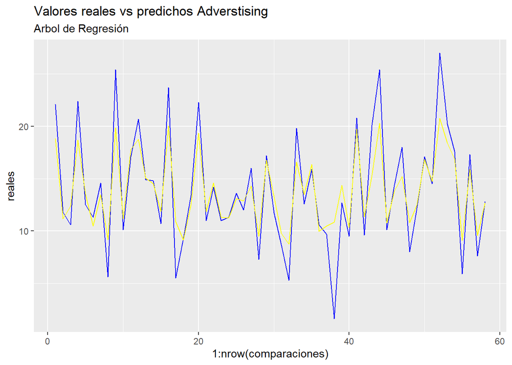

```r
ggplot(data = comparaciones) +
  geom_line(aes(x = 1:nrow(comparaciones), y = reales), col='blue') +
  geom_line(aes(x = 1:nrow(comparaciones), y = predicciones), col='yellow') +
  ggtitle(label="Valores reales vs predichos Adverstising", subtitle = "Arbol de Regresión")
```